# Google Pages

Apryl Perry

August 16, 2018

Previous example used default info that comes at the start of RMarkdown page.

Info was deleted for start of next example Next example is a bit more involved:

```r
suppressPackageStartupMessages({
  library(leaflet)
  library(dplyr)
  library(tidyr)
  library(ggplot2)
  library(DT)
})
```

Load salmon escapement data (note this code looks for the file in a local folder before pulling from web. You don’t need to download every time)

```r
data_url <- "https://knb.ecoinformatics.org/knb/d1/mn/v2/object/knb.92020.1"
# data_url <- "https://knb.ecoinformatics.org/knb/d1/mn/v2/object/urn%3Auuid%3Af119a05b-bbe7-4aea-93c6-85434dcb1c5e"
#use tryCatch function to look for local copy first, if you get an error, then the rest of the code, from error down, will run and then download the data from URL provided
esc <- tryCatch(
    read.csv("data/escapement.csv", stringsAsFactors = FALSE),
    error=function(cond) {
        message(paste(" Escapement file does not seem to exist, so get it from the KNB."))
        esc <- read.csv(url(data_url, method = "libcurl"), stringsAsFactors = FALSE)
        return(esc)
    }
)
```

```
##  Escapement file does not seem to exist, so get it from the KNB.
```

```r
head(esc)
```

```
##        Location SASAP.Region sampleDate Species DailyCount  Method
## 1 Akalura Creek       Kodiak 1930-05-24 Sockeye          4 Unknown
## 2 Akalura Creek       Kodiak 1930-05-25 Sockeye         10 Unknown
## 3 Akalura Creek       Kodiak 1930-05-26 Sockeye          0 Unknown
## 4 Akalura Creek       Kodiak 1930-05-27 Sockeye          0 Unknown
## 5 Akalura Creek       Kodiak 1930-05-28 Sockeye          0 Unknown
## 6 Akalura Creek       Kodiak 1930-05-29 Sockeye          0 Unknown
##   Latitude Longitude Source
## 1  57.1641 -154.2287   ADFG
## 2  57.1641 -154.2287   ADFG
## 3  57.1641 -154.2287   ADFG
## 4  57.1641 -154.2287   ADFG
## 5  57.1641 -154.2287   ADFG
## 6  57.1641 -154.2287   ADFG
```

Plot Median Annual Escapement by Species (using dash in data file as separator indicator to separate year, month, day into individual columns)

```r
median_esc <- esc %>%
  separate(sampleDate, c("Year", "Month", "Day"), sep = "-") %>%
  group_by(Species, SASAP.Region, Year, Location) %>%
  summarize(escapement = sum(DailyCount)) %>%
  group_by(Species) %>%
  summarize(median_escapement = median(escapement))

head(median_esc)
```

```
## # A tibble: 6 x 2
##   Species                 median_escapement
##   <chr>                               <dbl>
## 1 Anadromous dolly varden                 0
## 2 Chinook                               541
## 3 Chum                                  153
## 4 Chum - Fall                        430233
## 5 Chum - Summer                      642529
## 6 Coho                                 1978
```

Now plot the results as a bar chart (can create a style, then use a function and you can use time and time again w/o having to fight with labels, axis, etc) Plus sign is used to tell ggplot how to arrange, coord_flip flips x,y axis, geom_col is the style of the graphy (bar chart?) aes is a function that helps you map the data in your data frame to the plot.

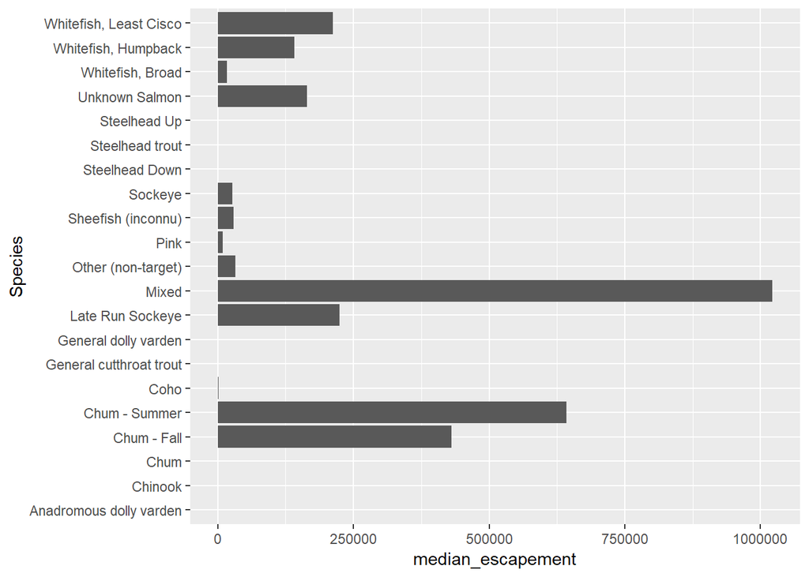

```r
ggplot(median_esc, aes(Species, median_escapement)) +
  geom_col() +
  coord_flip()
```

#Now working on building a map

We are starting from daily escapement data again and finding the unique locations at which escapement was measured.

Convert escapement data into a table of **unique locations** ##Find unique locations Remember to deal with missing values in the location field (in this case we are dropping them, but should really make sure you know why the data has missing values)

```r
locations <- esc %>%
  distinct(Location, Latitude, Longitude) %>%
  drop_na()
datatable(locations)
```

|  | Location | Latitude | Longitude |
| --- | --- | --- | --- |
| 1 | Akalura Creek | 57.1641 | -154.2287 |
| 4 | Anvik River | 62.7 | -160.2 |
| 6 | Ayakulik River | 57.1956 | -154.529 |
| 7 | Bear Creek | 56.0389 | -160.2734 |
| 8 | Bear River | 56.0389 | -160.2734 |
| 9 | Big Bay Creek | 58.5426 | -152.5683 |
| 10 | Big Kitoi Creek | 58.1915 | -152.3754 |
| 12 | Black Lake | 56.392 | -158.937 |
| 13 | Buskin River | 57.7768 | -152.5372 |
| 14 | Chelatna Lake | 62.4731 | 151.4545 |

[output cut: 58 more lines]

## Draw the map

```r
leaflet(locations) %>%
  addTiles() %>%
  addMarkers(~ Longitude, ~ Latitude, popup = ~ Location)
```

[interactive chart not shown]

##Fix leaflet output to correct for incorrect placement of markers

```r
locs <- locations %>% mutate(Longitude = abs(Longitude) * -1)

leaflet(locs) %>%
  addTiles() %>%
  addMarkers(~ Longitude, ~ Latitude, popup = ~ Location)
```

[interactive chart not shown]